# PEC1 - Anàlisi de dades òmiques

Aina Lluch Balaña

Abril 2020

[Repositori GitHub](https://github.com/ainalluch/FirstGitHubRep)

**CONTINGUT**

- Abstract
- Objectiu
- Materials i mètodes
  - Disseny experimental
  - Obtenció i caracterització de les dades
  - Control de qualitat de les dades crues
  - Normalització
  - Detecció dels gens més variables i filtrat dels menys variables
  - Design and contrast matrix
  - Estimació del model i selecció de gens diferencialment expressats
  - Vulcano plot
- Resultats
- Discussió/Comentari general
- Referències

## Abstract

Les neurones sensorials primàries del gangli de l’arrel dorsal (DRG) responen i retransmeten sensacions que es senten, com ara les de tacte, dolor, temperatura, picor, entre d’altres. Aquest es tracta d’un estudi de perfil d’expressió mitjançant un anàlisi per microarray de les neurones DRG a les quals se’ls hi ha eliminat la kinasa hepàtica B1 (LKB1) en l’espècie *Mus Musculus*.

## Objectiu

L’objectiu d’aquest estudi és descobrir canvis en l’expressió gènica en les neurones sensorials del ratolí quan s’elimina la kinasa hepàtica B1 (LKB1).

## Materials i mètodes

**Disseny experimental**

- mRNA extret a partir de neurones sensorials DRG directament aïllades d’embrions de ratolí.
- 5 rèpliques independents per cada genotip: *wild-type* (**WT**) o *knock-out* pel gen LKB1 (**LKB1 KO**). Fent un total de **10 mostres**.
- Microarray utilitzat: [MoGene-1_0-st] Affymetrix Mouse Gene 1.0 ST Array [transcript (gene) version].

**Obtenció i caracterització de les dades**

Les dades han sigut adquirides mitjançant el paquet *GEOquery* amb el número d’accés GSE146756 a la base de dades GEO. El resultat final és un *ExpressionSet* guardat en una *list*. Les dimensions del *dataset* és de 10 mostres i 35556 *features*.

```
## [1] "list"
```

```
## [1] 1
```

```
## [1] "ExpressionSet"
## attr(,"package")
## [1] "Biobase"
```

```
## ExpressionSet (storageMode: lockedEnvironment)
## assayData: 35556 features, 10 samples
##   element names: exprs
## protocolData: none
## phenoData
##   sampleNames: GSM4405436 GSM4405437 ... GSM4405445 (10 total)
##   varLabels: title geo_accession ... tissue:ch1 (32 total)
##   varMetadata: labelDescription
## featureData
##   featureNames: 10338001 10338002 ... 10608724 (35556 total)
##   fvarLabels: ID GB_LIST ... category (12 total)
##   fvarMetadata: Column Description labelDescription
## experimentData: use 'experimentData(object)'
## Annotation: GPL6246
```

```
##          exprs
## Features 35556
## Samples     10
```

```
##  [1] "title"                   "geo_accession"
##  [3] "status"                  "submission_date"
##  [5] "last_update_date"        "type"
##  [7] "channel_count"           "source_name_ch1"
##  [9] "organism_ch1"            "characteristics_ch1"
## [11] "characteristics_ch1.1"   "molecule_ch1"
## [13] "extract_protocol_ch1"    "label_ch1"
## [15] "label_protocol_ch1"      "taxid_ch1"
## [17] "hyb_protocol"            "scan_protocol"
## [19] "description"             "data_processing"
## [21] "platform_id"             "contact_name"
## [23] "contact_email"           "contact_institute"
## [25] "contact_address"         "contact_city"
## [27] "contact_zip/postal_code" "contact_country"
## [29] "supplementary_file"      "data_row_count"
## [31] "genotype/variaton:ch1"   "tissue:ch1"
```

```
##  [1] "wild type" "LKB1 KO"   "wild type" "LKB1 KO"   "wild type" "LKB1 KO"
##  [7] "wild type" "LKB1 KO"   "wild type" "LKB1 KO"
```

**Control de qualitat de les dades crues**

El control de qualitat de les dades, en aquest cas les no normalitzades, es pot fer mitjançant el paquet *arrayQualityMetrics*.

```r
#library(arrayQualityMetrics)
#arrayQualityMetrics(esetMM)
```

El resultat de l’anàlisi és el següent:

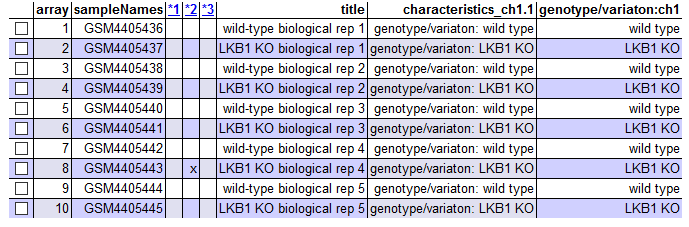

**Table 1: Array metadata and outlier detection overview**

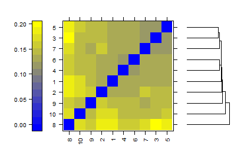

**Figure 1: Distances between arrays**

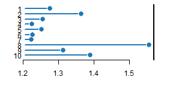

**Figure 2: Outlier detection for Distances between arrays**

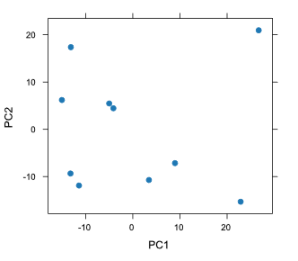

**Figure 3: Principal Component Analysis**

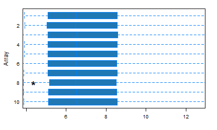

**Figure 4: Boxplot**

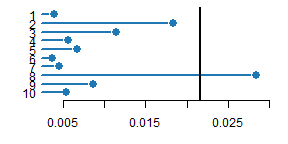

**Figure 5: Outlier detection for Boxplots**

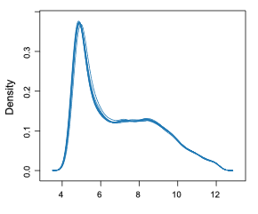

**Figure 6: Density plots**

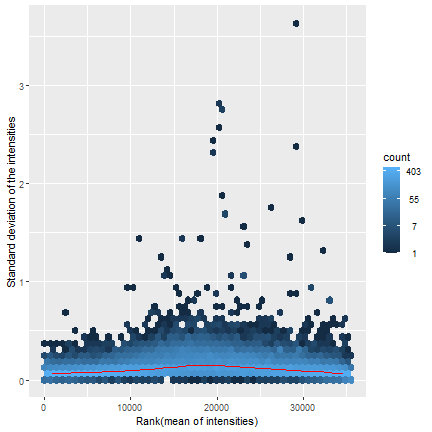

**Figure 7: Standard deviation versus rank of the mean**

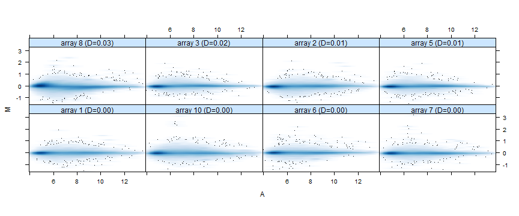

**Figure 8: MA plots**

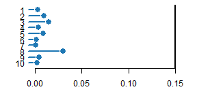

**Figure 9: Outlier detection for MA plots**

En l’anàlisi es pot observar com la mostra 8 (GSM405443), corresponent a una rèplica del grup LKB1 KO, és detectada com un *outlier* del conjunt de mostres, de manera que seria interessant no tenir-la en compte ja que pot distorsionar els resultats finals.

Exemple de boxplot fet amb Rstudio, equivalent al boxplot generat en l’anàlisi del paquet *arrayQualityMetrics*:

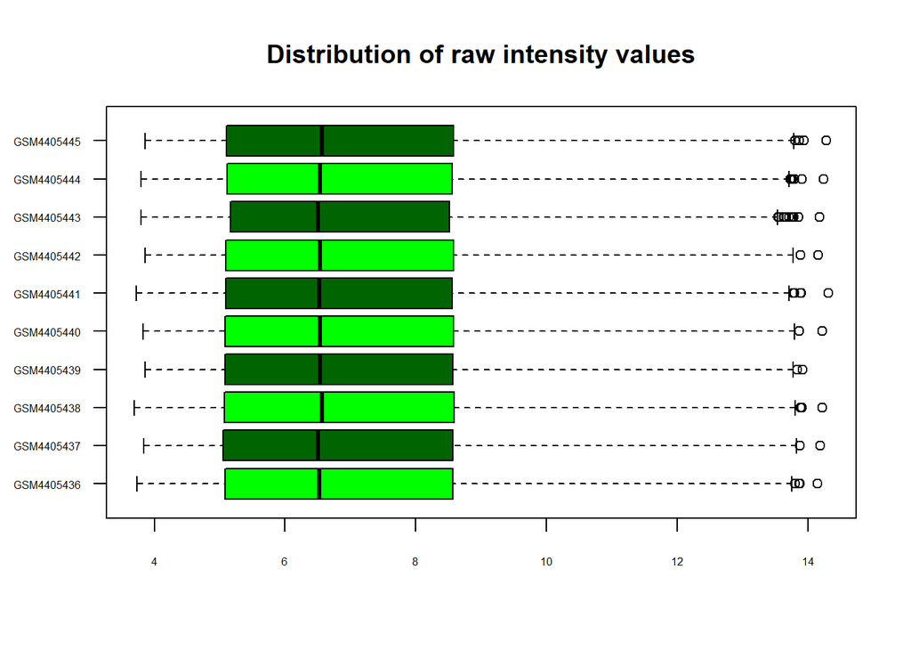

**Normalització**

```r
#library(oligo)
#esetMM_norm <- rma(esetMM)
```

Traceback del error:

Error in (function (classes, fdef, mtable) : unable to find an inherited method for function ‘rma’ for signature ‘“ExpressionSet”’

3.stop(gettextf(“unable to find an inherited method for function %s for signature %s”, sQuote(fdef@generic), sQuote(cnames)), domain = NA)

2.(function (classes, fdef, mtable) { methods <- .findInheritedMethods(classes, fdef, mtable) if (length(methods) == 1L) …

1.ma(esetMM)

COMENTARI:

- He provat d’assegurar-me que no hi haguessin els paquets affy i oligo activats a la vegada.
- Vaig descarregar el paquet oligo de nou.
- He provat amb ambdós paquets per separat.
- M’ha generat el mateix error en anteriors datasets amb els que he treballat per fer aquesta PEC i no he aconseguit normalitzar les dades en cap dels casos.

**Detecció dels gens més variables i filtrat dels menys variables**

Degut al error anterior, vaig decidir seguir treballant amb les dades sense normalitzar per tal de veure tot el procés. Aquí hi ha la gràfica de distribució de variabilitat del conjunt dels gens. Veiem que els gens que més varien són els que tenen una desviació estàndard per sobre del 95% de desvest (segona línia vertical):

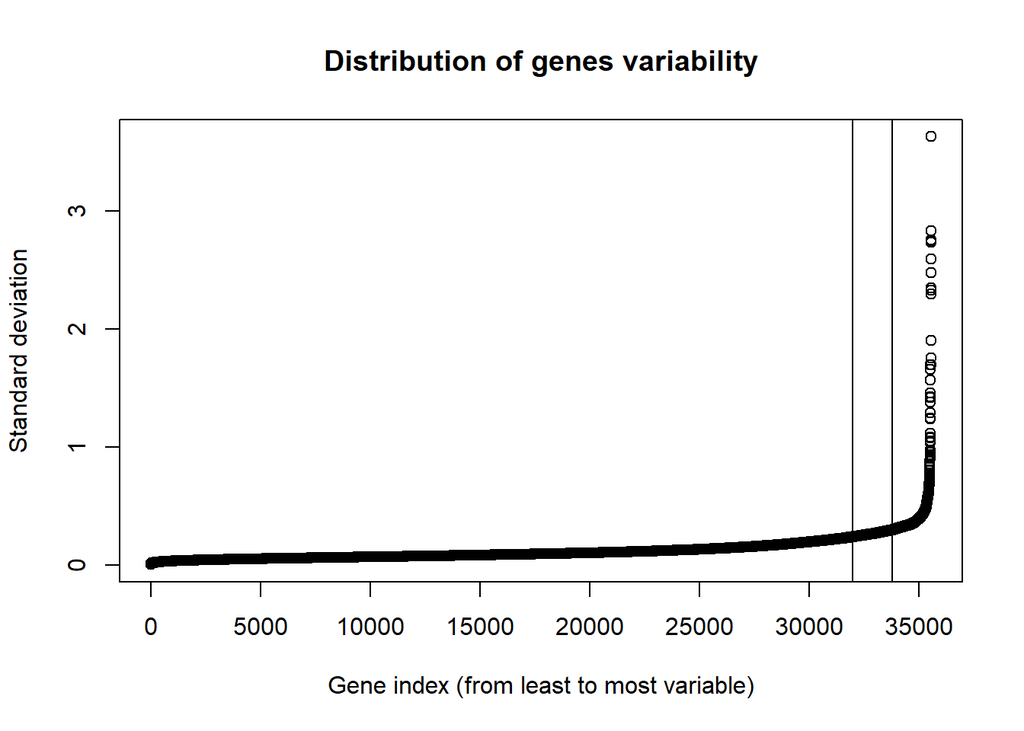

Per tal de dur a terme el filtrat, vaig descarregar el paquet d’anotacions corresponent al array utilitzat en l’estudi, que és el pd.mogene.1.0.st.v1. No he sabut corregir el motiu pel qual em dóna error.

```r
#library(genefilter)
#library(pd.mogene.1.0.st.v1)
#esetMM_filt <- nsFilter(esetMM, require.entrez = TRUE, remove.dupEntrez = TRUE, var.filter = TRUE, var.func = IQR, var.cutoff = 0.75, filterByQuantile = TRUE, feature.exclude = "^AFFX")
```

Error: getAnnMap: package GPL6246 not available

**Design and contrast matrix**

Tot i l’error generat, vaig decidir seguir per seguir veient el procés. La matriu generada:

```r
print(designMat)
```

```
##            KO WT
## GSM4405436  0  1
## GSM4405437  1  0
## GSM4405438  0  1
## GSM4405439  1  0
## GSM4405440  0  1
## GSM4405441  1  0
## GSM4405442  0  1
## GSM4405443  1  0
## GSM4405444  0  1
## GSM4405445  1  0
## attr(,"assign")
## [1] 1 1
## attr(,"contrasts")
## attr(,"contrasts")$`esetMM$`genotype/variaton:ch1``
## [1] "contr.treatment"
```

I la matriu de contrast, només hi ha una comparació en aquest estudi, que és KOvsWT:

```r
cont.matrix <- makeContrasts(KOvsWT = KO-WT, levels = designMat)
print(cont.matrix)
```

```
##       Contrasts
## Levels KOvsWT
##     KO      1
##     WT     -1
```

**Estimació del model i selecció de gens diferencialment expressats**

```
## [1] "MArrayLM"
## attr(,"package")
## [1] "limma"
```

```r
tableKOvsWT <- topTable(fit.main,number=nrow(fit.main), coef="KOvsWT")
head(tableKOvsWT[, 13:18])
```

```
##              logFC   AveExpr         t      P.Value    adj.P.Val        B
## 10432675  2.437318 10.051881  31.29451 9.637245e-12 3.426619e-07 13.55791
## 10368175  1.344368  8.710274  23.64151 1.782892e-10 3.169625e-06 12.26618
## 10348194 -1.579854  7.033673 -20.57907 7.479287e-10 8.864451e-06 11.47304
## 10422728  1.158040 10.739840  19.91941 1.046123e-09 9.298984e-06 11.27219
## 10498119  1.157230  8.493341  18.72678 1.972891e-09 1.402962e-05 10.87686
## 10413733  1.172686  7.152643  17.74256 3.429934e-09 2.032579e-05 10.51584
```

**Vulcano plot**

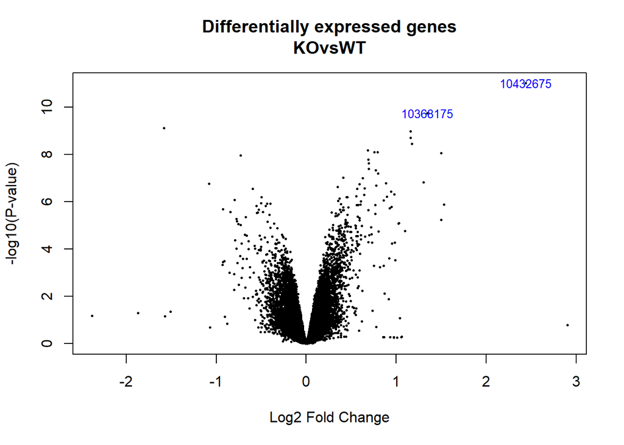

```r
tableKOvsWT[0:2, 2:2]
```

```
## [1] "NR_045781,NR_045782,AK146183"
## [2] "NM_013875,XM_006512758,XM_006512759,AF190639,AJ251859,AK049910,BC130267"
```

El primer (ID:10432675) correspon al gen RIKEN cDNA I730030J21

El segon (ID:10368175) correspon al gen phosphodiesterase 7B (Pde7b)

**Resultats**

De les parts que he pogut resoldre, la mostra 8 la extreuria de l’anàlisi. Quant als gens diferencialment expressats, tot i que ho he fet amb les dades crues i per tant no seria del tot correcte, els dos gens més significativament diferents entre els genotips KO i WT són el gen gen RIKEN cDNA I730030J21 i la phosphodiesterase 7B (Pde7b).

Queda pendent l’execució de l’anàlisi de significació biològica.

**Discussió/Comentari general**

L’informe que entrego no és complet. Alguns errors que m’han sorgit per normalitzar les dades i pel seu posterior filtratje, no he sigut capaç de solventar-los. Tot i així he decidit seguir amb l’anàlisi fent servir les dades crues per tal de simular el procés gairebé complet de l’anàlisi.

**Referències**

https://www.bioconductor.org/packages/release/bioc/vignettes/Biobase/inst/doc/ExpressionSetIntroduction.pdf)

http://bioconductor.org/packages/release/bioc/vignettes/oligo/inst/doc/oug.pdf

https://wiki.bits.vib.be/index.php/Analyze_your_own_microarray_data_in_R/Bioconductor

I tot el material proporcionat en l’assignatura